# Introduction to Econometrics: ECON 418-518

Inference Code

William Brasic The University of Arizona

23 September 2024

# Preliminaries

```r
# Clear environment, plot pane, and console
rm(list = ls())
graphics.off()
cat("\014")
```

```r
# Set working directory
setwd("C:/Users/wbras/OneDrive/Desktop/UA/Fall_2024/ECON_418-518/ECON_418-518_Lecture_Slides/ECON_418-518_Lecture_Slides_E/ECON_418-518_E_04_Inference/ECON_418-518_E_04_Inference_Code")

# Install pacman
if (!require(pacman)) install.packages("pacman")

# Load packages
pacman::p_load(data.table, ggplot2)

# Colors used for plot (https://www.rapidtables.com/web/color/RGB_Color.html)
color_1 <- "#00FF00"
color_2 <- "#ADD8E6"

# Disable scientific notation
options(scipen = 999)
```

# Graphs of t-Distribution and F-Distribution

## t-Distribution

The shape of t-distribution is determined by the degrees of freedom. Let’s see what this shape looks like.

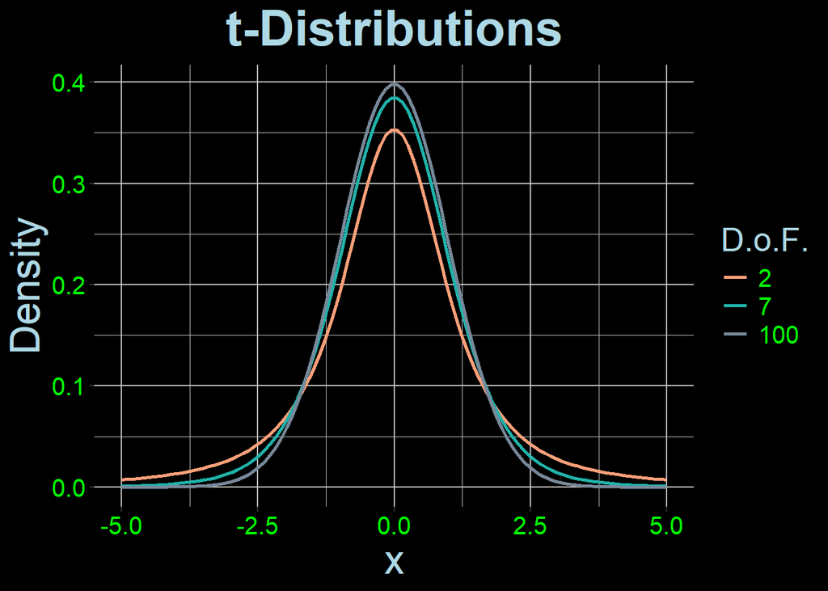

```r
# Create data table for T-distributions
df_t <- c(2, 7, 100)  # Degrees of freedom for t distribution
x_t <- seq(-5, 5, length.out = 100)

dt_t <- data.table(
  x = rep(x_t, times = 3),
  y = c(dt(x_t, df_t[1]), dt(x_t, df_t[2]), dt(x_t, df_t[3])),
  group = factor(rep(1:3, each = 100))
)

# Create the t-distribution plot
ggplot(dt_t, aes(x, y, color = group)) +
  geom_line(linewidth = 1) +
  labs(
    title = "t-Distributions",
    color = "D.o.F."  # Legend title
  ) +
  scale_color_manual(
    values = c("#FFA07A", "#20B2AA", "#778899"),
    labels = c("2", "7", "100")
  ) +
  theme(
    panel.background = element_rect(fill = "black", color = "black"),
    plot.background = element_rect(fill = "black", color = "black"),
    panel.grid.major = element_line(color = "gray"),
    panel.grid.minor = element_line(color = "gray"),
    axis.text = element_text(color = color_1, size = 15),
    axis.title = element_text(color = color_2, size = 25),
    plot.title = element_text(hjust = 0.5, color = color_2, size = 30, face = "bold"),
    plot.subtitle = element_text(hjust = 0.5, color = color_1, size = 25),
    legend.background = element_rect(fill = "black"),
    legend.text = element_text(color = color_1, size = 15),
    legend.title = element_text(color = color_2, size = 20)
  ) +
  expand_limits(y = 0) +
  xlab("x") +
  ylab("Density")
```

As you can see, this distribution is centered around zero for any degrees of freedom. Moreover, the tails get thinner as the degrees of freedom rises indicating the t-distribution converges towards the standard normal as the degrees of freedom tends to infinity.

## F-Distribution

The shape of F-distribution is determined by both its numerator and denonominator degrees of freedom. Let’s see what this shape looks like.

[figure not shown]

```r
# Create data table for F-distributions
df_f1 <- c(0.5, 10)  # Numerator degrees of freedom for F distribution
df_f2 <- c(0.5, 20)  # Denominator degrees of freedom for F distribution
x_f <- seq(0, 5, length.out = 100)

dt_f <- data.table(
  x = rep(x_f, times = 4),
  y = c(df(x_f, df_f1[1], df_f2[1]), df(x_f, df_f1[2], df_f2[2]), df(x_f, df_f1[1], df_f2[2]), df(x_f, df_f1[2], df_f2[1])),
  group = factor(rep(1:4, each = 100))
)

# Create the F distribution plot
ggplot(dt_f, aes(x, y, color = group)) +
  geom_line(linewidth = 1) +
  labs(
    title = "F-Distributions",
    color = "D.o.F."  # Legend title
  ) +
  scale_color_manual(
    values = c("#FF6347", "#32CD32", "#8A2BE2", "#FFD700"),
    labels = c("2, 10", "10, 20", "2, 20", "10, 10")
  ) +
  theme(
    panel.background = element_rect(fill = "black", color = "black"),
    plot.background = element_rect(fill = "black", color = "black"),
    panel.grid.major = element_line(color = "gray"),
    panel.grid.minor = element_line(color = "gray"),
    axis.text = element_text(color = color_1, size = 15),
    axis.title = element_text(color = color_2, size = 25),
    plot.title = element_text(hjust = 0.5, color = color_2, size = 30, face = "bold"),
    plot.subtitle = element_text(hjust = 0.5, color = color_1, size = 25),
    legend.background = element_rect(fill = "black"),
    legend.text = element_text(color = color_1, size = 15),
    legend.title = element_text(color = color_2, size = 20)
  ) +
  expand_limits(y = 0) +
  xlab("x") +
  ylab("Density")
```

We can see that the F-distribution is one sided; it only has one tail on the right and no tail on the left. This is similar to the $\chi^2$ distribution from which the F-distribution comes from. In fact, the F-distribution converges to the $\chi^2$ distribution as the F-distribution’s denominator degrees of freedom approaches infinity.

# Data Analysis with a `wooldridge` Dataset

```r
# Load in gpa2 dataset from wooldridge as a data table
dt <- data.table(wooldridge::econmath)

# Show the first few rows of the data
head(dt)
```

| age | work | study | econhs | colgpa | hsgpa | acteng | actmth | act | mathscr | male | calculus | attexc | attgood | fathcoll | mothcoll | score |
| --- | --- | --- | --- | --- | --- | --- | --- | --- | --- | --- | --- | --- | --- | --- | --- | --- |
| 23 | 15 | 10.0 | 0 | 3.4909 | 3.355 | 24 | 26 | 27 | 10 | 1 | 1 | 0 | 0 | 1 | 1 | 84.43 |
| 23 | 0 | 22.5 | 1 | 2.1000 | 3.219 | 23 | 20 | 24 | 9 | 1 | 0 | 0 | 0 | 0 | 1 | 57.38 |
| 21 | 25 | 12.0 | 0 | 3.0851 | 3.306 | 21 | 24 | 21 | 8 | 1 | 1 | 1 | 0 | 0 | 1 | 66.39 |
| 22 | 30 | 40.0 | 0 | 2.6805 | 3.977 | 31 | 28 | 31 | 10 | 0 | 1 | 0 | 1 | 1 | 1 | 81.15 |
| 22 | 25 | 15.0 | 1 | 3.7454 | 3.890 | 28 | 31 | 32 | 8 | 1 | 1 | 0 | 1 | 0 | 1 | 95.90 |
| 22 | 0 | 30.0 | 0 | 3.0555 | 3.500 | 25 | 30 | 28 | 10 | 1 | 1 | 1 | 0 | 0 | 1 | 83.61 |

```r
# Show the last few rows of the data
tail(dt)
```

| age | work | study | econhs | colgpa | hsgpa | acteng | actmth | act | mathscr | male | calculus | attexc | attgood | fathcoll | mothcoll | score |
| --- | --- | --- | --- | --- | --- | --- | --- | --- | --- | --- | --- | --- | --- | --- | --- | --- |
| 19 | 0 | 15.0 | 1 | 1.9482 | 3.318 | 19 | 27 | 24 | 9 | 1 | 1 | 0 | 1 | 0 | 0 | 75.00 |
| 19 | 10 | 9.0 | 0 | 3.2115 | 3.000 | 20 | 19 | 21 | 5 | 1 | 0 | 0 | 1 | 1 | 0 | 79.69 |
| 19 | 20 | 5.0 | 1 | 2.3888 | 3.071 | 23 | 23 | 22 | 10 | 1 | 1 | 0 | 1 | 0 | 0 | 78.13 |
| 19 | 20 | 21.5 | 1 | 3.1785 | 2.971 | 22 | 27 | 22 | 10 | 0 | 1 | 0 | 1 | 1 | 0 | 68.75 |
| 19 | 0 | 10.0 | 1 | 2.5892 | 3.861 | 21 | 19 | 21 | 9 | 0 | 0 | 0 | 1 | 1 | 0 | 77.34 |
| 19 | 0 | 15.0 | 1 | 3.7258 | 3.120 | 26 | 27 | 28 | 10 | 1 | 1 | 0 | 1 | 0 | 0 | 91.41 |

```r
# Only keep data on colgpa, hsgpa, act, and study
dt <- dt[, .(colgpa, hsgpa, act, study)]

# Show many NA values there are in the data
sum(is.na(dt))
```

```
## [1] 42
```

```r
# Drop rows with any NA values
dt <- na.omit(dt)

# Show many NA values there are in the data now
sum(is.na(dt))
```

```
## [1] 0
```

```r
# Get summary statistics
summary(dt)
```

```
##      colgpa          hsgpa            act            study
##  Min.   :0.875   Min.   :2.355   Min.   :13.00   Min.   : 0.00
##  1st Qu.:2.431   1st Qu.:3.114   1st Qu.:21.00   1st Qu.: 8.00
##  Median :2.806   Median :3.333   Median :23.00   Median :12.00
##  Mean   :2.811   Mean   :3.345   Mean   :23.12   Mean   :13.84
##  3rd Qu.:3.207   3rd Qu.:3.589   3rd Qu.:25.00   3rd Qu.:17.88
##  Max.   :4.000   Max.   :4.260   Max.   :33.00   Max.   :50.00
```

# T-Tests

Let’s conduct some T-Tests. We’ll first construct the T-statistics based on the report produced by `lm()`. Then, we’ll do this for T-Test One from scratch. The T-statistic produced in `R`’s regression output is given by $T = \frac{\widehat{\beta}}{\text{se}\left( \widehat{\beta} \right)}$ meaning it tests $H_0: \beta = 0$ versus $H_A: \beta \neq 0$.

## T-Tests Intuition

Let’s focus on the case of a two tailed test of $H_0: \beta_j = 0$ versus $H_A: \beta_j \neq 0$. Why should we reject the null (be confident that $\beta_j$ is different from zero) when $|T| > t_{1 - \frac{\alpha}{2}, n - k}$?

Let’s think about exactly what this T-statistic is. The T-statistic for the case of our specific hypothesis test is $T = \frac{\widehat{\beta}}{\text{se}\left( \widehat{\beta} \right)}$. Thus, a large $|T|$ either means $\widehat{\beta}_j$ is large in absolute value (far away from zero) or $\text{se}\left( \widehat{\beta}_j \right)$ is small. When $\widehat{\beta}_j$ is large in absolute value, we should be confident that $\beta_j$ is different from zero because its estimate is. When, $\text{se}\left( \widehat{\beta}_j \right)$ is small, that indicates we are more certain $\beta_j$ is different from zero (provided that $\widehat{\beta}_j \neq 0$) because a smaller standard error indicates more certanity surrounding the estimate.

Now, let’s think about exactly what this critical value is. The critical value for a two-tailed T-test is the value produced by the inverse CDF of the t-distribution with $n-k$ degrees of freedom when evaluated at $1 - \frac{\alpha}{2}$. Think about it this way: The CDF takes a number as input and returns the probability that a randomly selected value from the distribution is less than or equal to that input number while the inverse CDF takes a probability as input and returns the corresponding value such that this value is greater than or equal to that proportion of the distribution. Mathematically, the critical value is defined as
$$\begin{align}
t_{1 - \frac{\alpha}{2}, n - k}
&= F_{T_{n-k}}^{-1}\left(1 - \frac{\alpha}{2} \right).
\end{align}$$
where $F_{T_{n-k}}^{-1}$ is the inverse CDF of the t-distribution with $n-k$ degrees of freedom (takes in a probability and outputs a number rather than the other way around).

When $t_{1 - \frac{\alpha}{2}, n - k}$ is large our hypothesis test is harder to reject. This value is larger as $\alpha$ decreases which is why a test at $\alpha = 0.01$ is harder to reject than a test at $\alpha = 0.1$. A large $t_{1 - \frac{\alpha}{2}, n - k}$ means this value is larger than most T-distributed random variables with $n-k$ degrees of freedom. So, when $|T| > t_{1 - \frac{\alpha}{2}, n - k}$ holds true this means $|T|$ must be pretty large which implies either, as we discussed above, $\widehat{\beta}_j$ is large in absolute value or $\text{se}\left( \widehat{\beta}_j \right)$ is small. In either case, this gives evidence the null is false.

## T-Tests using `lm()`

Let’s use the `wooldridge` dataset `econmath` to analyze determinants of college GPA, `colgpa`. Here are the model’s covariates:

1. High school GPA, `hsgpa`
2. ACT score, `act`
3. Hours per week spent studying, `study`
4. Squared hours per week spent studying, `sq_study`. The rationale is that at some point studying so much may start to actually hurt your performance.

So, we are estimating the model
$$\begin{align}
colgpa_i = \beta_0 + \beta_1 hsgpa + \beta_2 act + \beta_3 study +
\beta_4 study^2 + u_i.
\end{align}$$

```r
# Get and show the number of observations
n <- nrow(dt)
cat("The number of observation is: ", n)
```

```
## The number of observation is:  814
```

```r
# Number of estimated parameters
k <- 4

# Create variable for the square of total hours per week spent studying
dt[, study_sq := study^2]

# Run regression of colgpa on covariates
reg <- lm(colgpa ~ hsgpa + act + study + study_sq, data = dt)

# Print the summary of reg
summary(reg)
```

```
##
## Call:
## lm(formula = colgpa ~ hsgpa + act + study + study_sq, data = dt)
##
## Residuals:
##      Min       1Q   Median       3Q      Max
## -1.80612 -0.30055  0.02035  0.33471  1.18006
##
## Coefficients:
##                 Estimate   Std. Error t value             Pr(>|t|)
## (Intercept) -0.023759108  0.174500199  -0.136                0.892
## hsgpa        0.648049922  0.053154305  12.192 < 0.0000000000000002 ***
## act          0.026520295  0.005488096   4.832           0.00000161 ***
## study        0.003921578  0.006589506   0.595                0.552
## study_sq    -0.000002247  0.000168500  -0.013                0.989
## ---
## Signif. codes:  0 '***' 0.001 '**' 0.01 '*' 0.05 '.' 0.1 ' ' 1
##
## Residual standard error: 0.4653 on 809 degrees of freedom
## Multiple R-squared:  0.2591, Adjusted R-squared:  0.2555
## F-statistic: 70.73 on 4 and 809 DF,  p-value: < 0.00000000000000022
```

#### T-Test One Using `lm()`

Let’s conduct the hypothesis test of $H_0: \beta_2 = 0$ versus $H_A: \beta_2 \neq 0$ at the $\alpha = 0.05$ level. The T-statistic for this test is the one reported by `R`’s `summary()` function in the column `t value`. Since we are interested in $\beta_2$, the T-statistic for our test is $4.832$. We need to find the t-critical value $t_{1 - \frac{\alpha}{2}, n - k} = t_{0.975, 809}$. Now, we use `R`’s `qt()` function to get the inverse CDF of the t-distribution. This inverse CDF will get the t-critical value for 809 degrees of freedom giving exactly 0.975 area to the left of it.

```r
# Get the t-critical value
t_crit <- qt(0.975, 809)

# Show the t-critical value
t_crit
```

```
## [1] 1.962901
```

Since $|T| = 4.832 > 1.96 = t_{0.975, 809}$, we reject the null hypothesis and conclude that $\beta_2$ is different from zero at the $\alpha = 0.05$ significance level (95% confidence level).

#### T-Test Two Using `lm()`

Let’s conduct the hypothesis test of $H_0: \beta_1 = 1$ versus $H_A: \beta_1 \neq 1$ at the $\alpha = 0.1$ level. The T-statistic for this test is not reported by `R`’s summary function so we must construct it ourselves. The T-statistic for this test is
$$\begin{align}
T
&= \frac{\widehat{\beta}_1 - 1}{\text{se} \left[ \widehat{\beta}_1
\right]} \\
&= \frac{0.648 - 1}{0.053} \\
&= -6.642
\end{align}$$

Now, we need to find the t-critical value $t_{1 - \frac{\alpha}{2}, n - k} = t_{0.95, 809}$. We use `R`’s `qt()` function to get the inverse CDF of the t-distribution. This inverse CDF will get the t-critical value for 809 degrees of freedom giving exactly 0.95 area to the left of it.

```r
# Get the t-critical value
t_crit <- qt(0.95, 809)

# Show the t-critical value
t_crit
```

```
## [1] 1.646739
```

#### T-Test Three Using `lm()`

Let’s conduct the hypothesis test of $H_0: \beta_1 \leq 0.5$ versus $H_A: \beta_1 > 0.5$ at the $\alpha = 0.05$ level. This is a right tailed test and the T-statistic for this test is not reported by `R`’s summary function so we must construct it ourselves. The T-statistic for this test is
$$\begin{align}
T
&= \frac{\widehat{\beta}_1 - 0.5}{\text{se} \left[
\widehat{\beta}_1 \right]} \\
&= \frac{0.648 - 0.5}{0.053} \\
&= 2.792
\end{align}$$

Now, we need to find the t-critical value $t_{1 - \alpha, n - k} = t_{0.95, 809}$. We use `R`’s `qt()` function to get the inverse CDF of the t-distribution. This inverse CDF will get the t-critical value for 809 degrees of freedom giving exactly 0.95 area to the left of it.

```r
# Get the t-critical value
t_crit <- qt(0.95, 809)

# Show the t-critical value
t_crit
```

```
## [1] 1.646739
```

Since $T = 2.792 > 1.64 = t_{0.95, 809}$, we reject the null hypothesis and conclude that $\beta_1$ is greater than one-half at the $\alpha = 0.05$ significance level (95% confidence level).

#### T-Test Four Using `lm()`

Let’s conduct the hypothesis test of $H_0: \beta_2 \geq 0.03$ versus $H_A: \beta_2 < 0.03$ at the $\alpha = 0.01$ level. This is a left tailed test and the T-statistic for this test is not reported by `R`’s summary function so we must construct it ourselves. The T-statistic for this test is
$$\begin{align}
T
&= \frac{\widehat{\beta}_2 - 0.03}{\text{se} \left[
\widehat{\beta}_1 \right]} \\
&= \frac{0.027 - 0.03}{0.0054} \\
&= -0.555
\end{align}$$

Now, we need to find the t-critical value $t_{\alpha, n - k} = t_{0.01, 809}$. We use `R`’s `qt()` function to get the inverse CDF of the t-distribution. This inverse CDF will get the t-critical value for 809 degrees of freedom giving exactly 0.01 area to the left of it.

```r
# Get the t-critical value
t_crit <- qt(0.01, 809)

# Show the t-critical value
t_crit
```

```
## [1] -2.330966
```

Since $T = -0.555 > -2.33 = t_{0.01, 810}$, we fail to reject the null hypothesis and cannot conclude $\beta_2 < 0.03$ at the $\alpha = 0.01$ significance level (99% confidence level).

## T-Tests from Scratch

Let’s create the test statistics produced by `R`’s `summary()` function by hand. The `summary()` table can be derived from left to right. That is, we first obtain the parameter estimates by computing $(X^\prime X)^{-1} X^\prime \boldsymbol{y}$. Then, we obtain the standard errors, use those standard errors to get the T-statistics, and then use those T-statistics to get the p-values.

#### Parameter Estimates

```r
# Make our y vector
y <- dt[, colgpa]

# Make a vector of 1's to add as the first column of our X matrix for the intercept
Intercept <- rep(1, nrow(dt))

# Now lets construct our X matrix
X <- as.matrix(cbind(Intercept, dt[, .(hsgpa, act, study, study_sq)]))

# Show the first 5 rows and all columns of X
X[1:5, ]
```

```
##      Intercept hsgpa act study study_sq
## [1,]         1 3.355  27  10.0   100.00
## [2,]         1 3.219  24  22.5   506.25
## [3,]         1 3.306  21  12.0   144.00
## [4,]         1 3.977  31  40.0  1600.00
## [5,]         1 3.890  32  15.0   225.00
```

```r
# Transpose of X
Xprime <- t(X)

# Compute the OLS solution for beta_hat
beta_hat <- solve(Xprime %*% X) %*% Xprime %*% y

# Show beta_hat
beta_hat
```

```
##                      [,1]
## Intercept -0.023759107645
## hsgpa      0.648049922299
## act        0.026520294947
## study      0.003921578066
## study_sq  -0.000002246773
```

Notice this is identical to that produced by `R`’s `summary()` function like we would expect.

#### Standard Errors

```r
# Number of observations
n <- nrow(X)

# Number of estimated parameters (including intercept)
k <- ncol(X)

# Obtain the estimated residuals
u_hat <- y - X %*% beta_hat

# Obtain the variance of u_hat (n - k accounts for the degree of freedom correction)
sigma_hat_sq <- sum(u_hat^2) / (n - k)

# Get inverse of X_prime %*% X
Xprime_X_inverse <- solve(Xprime %*% X)

# Obtain the estimated variance covariance matrix
var_cov <- sigma_hat_sq * Xprime_X_inverse

# Get the diagonal elements of the estimated variance-covaraince matrix (elements along diagonal are the variance of each parameter)
beta_hat_var <- diag(var_cov)

# Take the square root of the estimated variance of the estimated parameters to get the standard error
beta_hat_se <- sqrt(beta_hat_var)

# Show the standard errors
beta_hat_se
```

```
##    Intercept        hsgpa          act        study     study_sq
## 0.1745001987 0.0531543048 0.0054880963 0.0065895064 0.0001685002
```

Notice this is identical to that produced by `R`’s `summary()` function like we would expect.

## Obtain the T-statistics Manually

We use the created standard errors to generate the test statistics. Please note, these are the test statistics associated with the test of $H_0: \beta_j = 0$ versus $H_A: \beta_j \neq 0$.

```r
# Divide beta_hat by its standard error to get its T-statistic
beta_hat_t <- beta_hat / beta_hat_se

# Show the T-statistics
beta_hat_t
```

```
##                  [,1]
## Intercept -0.13615519
## hsgpa     12.19186150
## act        4.83233046
## study      0.59512471
## study_sq  -0.01333395
```

Notice this is identical to that produced by `R`’s `summary()` function like we would expect.

# p-Values

## p-Value Intuition

The p-value associated with our OLS estimators is given by
$$\begin{align}
p
&= 2 * \mathbb{P} \left( T_{n - k} > |T| \right) \\
&= 2 * \left(1 - F_{T_{n-k}} \left( |T| \right) \right)
\end{align}$$
where $F_{T_{n-k}}$ is the CDF of the t-distribution with $n-k$ degrees of freedom, $T_{n-k}$ is any t-distributed random variable with $n-k$ degrees of freedom, and $T$ is our test statistic which has a t-distribution with $n-k$ degrees of freedom.

What exactly is the intuition of the p-value? Well, the ones given in the output of the `summary()` function are associated with hypothesis tests of $H_0: \beta_j = 0$ versus $H_A: \beta_j \neq 0$. So, if our p-value is small that means $2 * \mathbb{P} \left( T_{n - k} > |T| \right)$ is small which is to say $\mathbb{P} \left( T_{n - k} > |T| \right)$ is small. Thus, $|T|$ is likely pretty large.

$T = \frac{\widehat{\beta}_j}{\text{se}\left( \widehat{\beta}_j \right)}$ so a large $|T|$ either means $\widehat{\beta}_j$ is large in absolute value (far away from zero) or $\text{se}\left( \widehat{\beta}_j \right)$ is small. When $\widehat{\beta}_j$ is large in absolute value, we should be confident that $\beta_j$ is different from zero. When, $\text{se}\left( \widehat{\beta}_j \right)$ is small, that indicates we are more certain $\beta_j$ is different from zero (provided that $\widehat{\beta}_j \neq 0$). Either case produces a larger test statistic $T$ implying a smaller p-value $p$.

We can construct one-sided p-values to conduct either left or right-sided tests, but I’ve never seen this done in practice so we won’t worry about it here.

## p-Values Using `lm()`

p-values are derived from the T-statistics. Let’s recall out regression output:

```r
# Print the summary of reg
summary(reg)
```

```
##
## Call:
## lm(formula = colgpa ~ hsgpa + act + study + study_sq, data = dt)
##
## Residuals:
##      Min       1Q   Median       3Q      Max
## -1.80612 -0.30055  0.02035  0.33471  1.18006
##
## Coefficients:
##                 Estimate   Std. Error t value             Pr(>|t|)
## (Intercept) -0.023759108  0.174500199  -0.136                0.892
## hsgpa        0.648049922  0.053154305  12.192 < 0.0000000000000002 ***
## act          0.026520295  0.005488096   4.832           0.00000161 ***
## study        0.003921578  0.006589506   0.595                0.552
## study_sq    -0.000002247  0.000168500  -0.013                0.989
## ---
## Signif. codes:  0 '***' 0.001 '**' 0.01 '*' 0.05 '.' 0.1 ' ' 1
##
## Residual standard error: 0.4653 on 809 degrees of freedom
## Multiple R-squared:  0.2591, Adjusted R-squared:  0.2555
## F-statistic: 70.73 on 4 and 809 DF,  p-value: < 0.00000000000000022
```

Notice the `***` on the right side associated with the estimates of `hsgpa` and `act` as well as the `Signif. codes`. A triple `***` means we reject the null hypothesis of $\beta_j = 0$ at the $\alpha = 0.001$ significance level. A double `**` means we reject the null hypothesis of $\beta_j = 0$ at the $\alpha = 0.01$ significance level. A single `*` means we reject the null hypothesis of $\beta_j = 0$ at the $\alpha = 0.05$ significance level. A single `.` means we reject the null hypothesis of $\beta_j = 0$ at the $\alpha = 0.1$ significance level.

We can construct these p-values using `R`’s `pt()` function. This corresponds to the CDF of the t-distribution. Let’s get the p-value associated with the `act` estimate.

```r
# Use pt (CDF of T-distribution) to get the p-value
beta_hat_p <- 2 * pt(abs(4.832), n - k, lower.tail = FALSE)

# Show the p-values
beta_hat_p
```

```
## [1] 0.000001617101
```

We could also have ran the following code and gotten the same result.

```r
# Use pt (CDF of T-distribution) to get the p-value
beta_hat_p <- 2 * (1 - pt(abs(4.832), n - k, lower.tail = TRUE))

# Show the p-values
beta_hat_p
```

```
## [1] 0.000001617101
```

This is because `2 * pt(abs(4.832), n - k, lower.tail = FALSE)` corresponds to $2 * \mathbb{P} \left( T_{n - k} > |T| \right)$ so we assign `lower.tail = FALSE` because we want the probability that any $T_{n-k}$ random variable is greater than the absolute value of test statistic (think greater than so we want the upper tail, i.e., `lower.tail = FALSE`). Moreover, `2 * (1 - pt(abs(4.832), n - k, lower.tail = TRUE))` corresponds to $2 * \left(1 - F_{T_{n-k}} \left(|T| \right) \right)$ so we assign `lower.tail = TRUE` because we want the probability that any $T_{n-k}$ random variable is less than or equal to the absolute value of test statistic (think less than so we want the lower tail, i.e., `lower.tail = TRUE`).

## Obtain the p-Values Manually

We use the created test statistics to generate the p-values. Please note, these are the p-values associated with the test of $H_0: \beta_j = 0$ versus $H_A: \beta_j \neq 0$.

```r
# Use pt (CDF of t-distribution) to get the p-value
beta_hat_p <- 2 * pt(abs(beta_hat_t), n - k, lower.tail = FALSE)

# Show the p-values
beta_hat_p
```

```
##                                             [,1]
## Intercept 0.891732471362761458522072643972933292
## hsgpa     0.000000000000000000000000000000165226
## act       0.000001614493989861939950408026289708
## study     0.551926539161966323021601965592708439
## study_sq  0.989364651553847451737055962439626455
```

Notice this is identical to that produced by `R`’s `summary()` function like we would expect.

# Confidence Intervals

Confidence intervals are extremely important in econometrics and applied statistics. I can guarantee you they will show up in your applied work and I can almost guarantee you they will show up on your exam 😊.

## Confidence Intervals Intuition

A $100(1 - \alpha)\%$ confidence interval for $\beta_j$ is given by
$$\begin{align}
\left[ \widehat{\beta}_j - t_{1 - \frac{\alpha}{2}, n - k} \cdot
\text{se} \left(\widehat{\beta}_j \right), \, \widehat{\beta}_j + t_{1
- \frac{\alpha}{2}, n - k} \cdot \text{se}\left(\widehat{\beta}_j
\right) \right]
\end{align}$$
If you are wondering why this confidence interval is the way it is, I proved this result in the `ECON_418-518_E_04_Inference` lecture slides.

The intuition of a confidence interval is pretty straightforward.

1. Suppose we are interested in the test of $H_0: \beta_j = 0$ versus $\beta_j \neq 0$ at the $\alpha$ significance level. If zero lies in this interval, then we fail to reject the null at the $100(1 - \alpha)\%$ confidence level. Otherwise, we reject the null and conclude we are $100(1 - \alpha)\%$ confident that $\beta_j$ is different from zero.
2. Suppose we are interested in the test of $H_0: \beta_j = 1$ versus $\beta_j \neq 1$. If one lies in this interval, then we fail to reject the null at the $100(1 - \alpha)\%$ confidence level. Otherwise, we reject the null and conclude we are $100(1 - \alpha)\%$ confident that $\beta_j$ is different from one.

We can construct one-sided confidence intervals to conduct either left or right-sided tests, but I’ve never seen this done in practice so we won’t worry about it here.

## Confidence Intervals using `lm()`

One poor aspect of `R`’s summary function is that it doesn’t directly give us confidence intervals for our parameters. However, we can easily obtain a confidence interval for each parameter using `R`’s `confint()` function.

```r
# Show the 90% confidence interval for each parameter
confint(reg, level = 0.90)
```

```
##                       5 %         95 %
## (Intercept) -0.3111154463 0.2635972310
## hsgpa        0.5605186385 0.7355812061
## act          0.0174828310 0.0355577589
## study       -0.0069296213 0.0147727774
## study_sq    -0.0002797227 0.0002752291
```

```r
# Show the 95% confidence interval for each parameter
confint(reg, level = 0.95)
```

```
##                     2.5 %       97.5 %
## (Intercept) -0.3662856615 0.3187674462
## hsgpa        0.5437133028 0.7523865418
## act          0.0157477071 0.0372928828
## study       -0.0090129684 0.0168561245
## study_sq    -0.0003329959 0.0003285023
```

```r
# Show the 99% confidence interval for each paramter
confint(reg, level = 0.99)
```

```
##                     0.5 %       99.5 %
## (Intercept) -0.4743046851 0.4267864698
## hsgpa        0.5108097522 0.7852900924
## act          0.0123504686 0.0406901213
## study       -0.0130920013 0.0209351574
## study_sq    -0.0004373008 0.0004328072
```

## Obtain the Confidence Intervals Manually

Let’s manually construct a 95% confidence interval for `act` and carry out the hypothesis test $H_0: \beta_2 = 0$ versus $H_A: \beta_2 \neq 0$.

```r
# Let's get the T-critical value for a 95% confidence level test
t_crit <- qt(0.975, df = n - k)

# Create a vector that holds the left and right endpoints of the confidence interval
ci <- c(beta_hat[3] - t_crit * beta_hat_se[3], beta_hat[3] + t_crit * beta_hat_se[3])

# Show the vector
ci
```

```
##        act        act
## 0.01574771 0.03729288
```

Notice this is identical to that produced by `R`’s `confint()` function. Moreover, zero is not contained in this interval so we reject the null hypothesis of $\beta_j = 0$ and conclude that $\beta_j \neq 0$ with 95% confidence.

# F-Tests

F-Tests are used to conduct tests regarding joint significance. Suppose we wish to test $H_0: \beta_3 = \beta_4 = 0$ versus $H_A: \beta_3 \neq 0 \ \text{or} \ \beta_4 \neq 0$ at the $\alpha$ significance level. If we fail to reject the null, we can conclude both parameters are statistically insignificant at the $\alpha$ significance level with a single F-test rather than two individual T-tests. However, when we reject this null, we still need to carry out individual T-tests to determine if $\beta_3 \neq 0$, $\beta_4 \neq 0$, or both are non-zero.

Although our null and alternative hypothesis has equalities instead of inequalities, there is no need to divide $\alpha$ by two when obtaining the critical value like we usually do for two tailed tests. This is because the F-distribution only has one tail on the right side. See the graph of various F-distributions for various degrees of freedom in the `F-Distribution` section above.

## F-Tests Intuition

Let’s focus on the case of the test $H_0: \beta_3 = \beta_4 = 0$ versus $H_A: \beta_3 \neq 0 \ \text{or} \ \beta_4 \neq 0$. Why should we reject the null (be confident that one of these parameters is different from zero) when $F > f_{1 - \alpha, q, n - k}$?

Let’s think about exactly what this F-statistic is. The F-statistic is defined as
$$\begin{align}
F = \frac{(SSR_r - SSR_{ur}) / q}{SSR_{ur} / (n - k)}
\end{align}$$
which follows an F-distribution with $q$ numerator degrees of freedom and $n-k$ denominator degrees of freedom. $SSR_r$ is the sum of the squared residuals from the restricted model, $SSR_{ur}$ is the sum of the squared residuals from the unrestricted model, $q$ is the number of restrictions (think about this as the number of equal signs in the null hypothesis), and $n-k$ is the degrees of freedom where $k$ is the number of estimated parameters (intercept included). When this F-statistic large (meaning we are more likely to reject the null) this means either $(SSR_r - SSR_{ur}) / q$ is large or $SSR_{ur} / (n - k)$ is small. Let’s think about both cases:

1. When $(SSR_r - SSR_{ur}) / q$ is large either $(SSR_r - SSR_{ur})$ is large or $q$ is small. When $(SSR_r - SSR_{ur})$ is large we know our restricted model has a larger sum of squared residuals relative to our unrestricted model indicating excluding $\beta_3$ and $\beta_4$ hurts our model’s performance so it is likely at least one of these parameters is non-zero (the null is false). $q$ is simply a degrees of freedom correction ensuring our F-statistic follows an F-distribution
2. When $SSR_{ur} / (n - k)$ is small either $SSR_{ur}$ is small or $n - k$ is large. When $SSR_{ur}$ is small the unrestricted model has a small sum of squared residuals. This means it does a good job predicting our outcome indicating that $\beta_3$ and $\beta_4$ should remain in our model (the null is false). $n-k$ is simply a degrees of freedom correction ensuring our F-statistic follows an F-distribution.

Now, let’s think about exactly what this critical value is. The critical value for a F-test is the value produced by the inverse CDF of the f-distribution with $q$ numerator degrees of freedom and $n-k$ denominator degrees of freedom when evaluated at $1 - \alpha$. Think about it this way: The CDF takes a number as input and returns the probability that a randomly selected value from the distribution is less than or equal to that input number while the inverse CDF takes a probability as input and returns the corresponding value such that this value is greater than or equal to that proportion of the distribution. Mathematically, the critical value is defined as
$$\begin{align}
f_{1 - \alpha, q, n - k}
&= F_{f_{q, n-k}}^{-1}\left(1 - \alpha \right).
\end{align}$$
where $F_{f_{q, n-k}}^{-1}$ is the inverse CDF of the F-distribution with $q$ numerator degrees of freedom and $n-k$ denominator degrees of freedom (takes in a probability and outputs a number rather than the other way around).

When $f_{1 - \alpha, q, n - k}$ is large our hypothesis test is harder to reject. This value is larger as $\alpha$ decreases which is why a test at $\alpha = 0.01$ is harder to reject than a test at $\alpha = 0.1$. A large $f_{1 - \alpha, q, n - k}$ means it is larger than most F-distributed random variables. So, when $F > f_{1 - \alpha, q, n - k}$ this means $F$ must be pretty large which implies either, as we discussed above, $(SSR_r - SSR_{ur}) / q$ is large or $SSR_{ur} / (n - k)$ is small. In either case, this gives evidence the null is false.

## F-Tests using `lm()`

Recall our regression summary:

```r
# Show regression summary
summary(reg)
```

```
##
## Call:
## lm(formula = colgpa ~ hsgpa + act + study + study_sq, data = dt)
##
## Residuals:
##      Min       1Q   Median       3Q      Max
## -1.80612 -0.30055  0.02035  0.33471  1.18006
##
## Coefficients:
##                 Estimate   Std. Error t value             Pr(>|t|)
## (Intercept) -0.023759108  0.174500199  -0.136                0.892
## hsgpa        0.648049922  0.053154305  12.192 < 0.0000000000000002 ***
## act          0.026520295  0.005488096   4.832           0.00000161 ***
## study        0.003921578  0.006589506   0.595                0.552
## study_sq    -0.000002247  0.000168500  -0.013                0.989
## ---
## Signif. codes:  0 '***' 0.001 '**' 0.01 '*' 0.05 '.' 0.1 ' ' 1
##
## Residual standard error: 0.4653 on 809 degrees of freedom
## Multiple R-squared:  0.2591, Adjusted R-squared:  0.2555
## F-statistic: 70.73 on 4 and 809 DF,  p-value: < 0.00000000000000022
```

#### Intercept Only Model

Let’s conduct the test of $H_0: \beta_1 = \beta_2 = \beta_3 = \beta_4 = 0$ versus $H_A: \text{One of these coefficients is non-zero}$ at the $\alpha = 0.01$ significance level. This corresponds to a restricted model of
$$\begin{align}
colgpa_i = \beta_0 + v_i
\end{align}$$
and an unrestricted model of
$$\begin{align}
colgpa_i = \beta_0 + \beta_1 hsgpa + \beta_2 act + \beta_3 study +
\beta_4 study^2 + u_i.
\end{align}$$

In the case of the restricted model, $\displaystyle \widehat{\beta}_0 = \frac{1}{n} \sum_{i=1}^n colgpa_i = \overline{colgpa}$. So, we are essentially testing if the average of college GPA is a better predictor than trying to predict it with high school GPA, ACT scores, and hours studied per week.

In this specific case, the F-stat for this test of $F = 70.73$ is reported by `R`’s `summary()` function near the bottom with the associated p-value of $p = 2.2e^{-16}$ to the right of it as well as the numerator degrees of freedom of $q = 4$ and the denominator degrees of freedom of $n - k = 814 - 5 = 809$. Since the p-value is much lower than $\alpha = 0.01$, we can reject the null hypothesis and conclude at least one of the coefficients is non-zero. However, to conclude which of them is non-zero we must carry out individual T-tests.

Let’s verify these results by computing the F-statistic and its p-value manually. Recall that the F-distribution is only right tailed so there is no need to multiply the p-value by two.

```r
# Significance level
alpha <- 0.01

# Number of restrictions
q <- 4

# Number of estimated parameters of the unrestricted model
k_ur <- 5

# Number of estimated parameters of the restricted model
k_r <- k_ur - q

# Unrestricted regression
reg_ur <- lm(colgpa ~ hsgpa + act + study + study_sq, data = dt)

# Restricted regression
reg_r <- lm(colgpa ~ 1, data = dt)

# SSR for unrestricted model
SSR_ur <- sum(reg_ur$residuals^2)

# SSR for restricted model
SSR_r <- sum(reg_r$residuals^2)

# Numerator for F-statistic
F_stat_num <- (SSR_r - SSR_ur) / q

# Denominator for F-statistic
F_stat_denom <- SSR_ur / (n - k_ur)

# F-statistic
F_stat <- F_stat_num / F_stat_denom

# Show the F-statistic
cat("The F-statistic is: ", F_stat, "\n")
```

```
## The F-statistic is:  70.7337
```

```r
# F-critical value
f_crit <- qf(1 - alpha, df1 = q, df2 = n - k)

# Show the F-critical value
cat("The F-critical value is: ", f_crit, "\n")
```

```
## The F-critical value is:  3.342404
```

```r
# Use pf (CDF of F-distribution) to get the p-value
F_stat_p <- pf(F_stat, df1 = q, df2 = n - k, lower.tail = FALSE)

# Show the p-value on the F-statistic
cat("The p-value associated with the F-statistic is: ", F_stat_p)
```

```
## The p-value associated with the F-statistic is:  0.000000000000000000000000000000000000000000000000002183434
```

Notice this is identical to that produced by `R`’s `summary()` function.

Since $F = 70.73 > 3.34 = f_{1 - \alpha, q, n-k}$, we reject the null like the p-value indicates.

We could have used the formula
$$\begin{align}
F = \frac{R^2 / (k - 1)}{(1 - R^2) / (n - k)}
\end{align}$$
and gotten identical results because we are testing the null hypothesis of an intercept only model. Note, this formula only works when testing this specific null hypothesis. Let’s verify this.

```r
# Number of estimated parameters including intercept
k <- 5

# Number of observations
n <- nrow(dt)

# Obtain outcome from our data table
y <- dt[, colgpa]

# Obtain the residuals
u_hat <- y - X %*% beta_hat

# Obtain the total sum of squares (SST)
SST <- sum((y - mean(y))^2)

# Get the residual sum of squares (SSR)
SSR <- sum((u_hat)^2)

# Use the SST and SSR to get the R-squared
r_squared <- 1 - (SSR / SST)

# Compute the numerator of the F-statistic
F_stat_num <- r_squared / (k - 1)

# Compute the denominator of the F-statistic
F_stat_denom <- (1 - r_squared) / (n - k)

# Compute the F-statistic
F_stat <- F_stat_num / F_stat_denom

# Show the F-statistic
cat("The F-statistic is: ", F_stat)
```

```
## The F-statistic is:  70.7337
```

Notice this is exactly identical to that produced by `R`’s `lm()` function.

Moreover, let’s use `R`’s `anova` function to replicate these results. This is very useful and does most of the work for us.

```r
# Unrestricted regression
reg_ur <- lm(colgpa ~ hsgpa + act + study + study_sq, data = dt)

# Restricted regression
reg_r <- lm(colgpa ~ 1, data = dt)

# F-Test Summary
anova(reg_r, reg_ur)
```

|  | Res.Df | RSS | Df | Sum of Sq | F | Pr(>F) |
| --- | --- | --- | --- | --- | --- | --- |
| 1 | 813 | 236.3623 | NA | NA | NA | NA |
| 2 | 809 | 175.1177 | 4 | 61.24461 | 70.7337 | 0.000000000000000000000000000000000000000000000000002183434 |

Notice in the second row of the table we get the F-statistic and the p-value associated with it (click on the arrow to the right of `F` to see the p-value).

#### Two Restrictions

Let’s conduct the test of $H_0: \beta_3 = \beta_4 = 0$ versus $H_A: \text{One of these coefficients is non-zero}$ at the $\alpha = 0.1$ significance level. This corresponds to a restricted model of
$$\begin{align}
colgpa_i = \beta_0 + \beta_1 hsgpa + \beta_2 act + v_i
\end{align}$$
and an unrestricted model of
$$\begin{align}
colgpa_i = \beta_0 + \beta_1 hsgpa + \beta_2 act + \beta_3 study +
\beta_4 study^2 + u_i.
\end{align}$$

```r
# Significance level
alpha <- 0.1

# Number of restrictions
q <- 2

# Number of estimated parameters of the unrestricted model
k_ur <- 5

# Number of estimated parameters of the restricted model
k_r <- k_ur - q

# Unrestricted regression
reg_ur <- lm(colgpa ~ hsgpa + act + study + study_sq, data = dt)

# Restricted regression
reg_r <- lm(colgpa ~ hsgpa + act, data = dt)

# SSR for unrestricted model
SSR_ur <- sum(reg_ur$residuals^2)

# SSR for restricted model
SSR_r <- sum(reg_r$residuals^2)

# Numerator for F-statistic
F_stat_num <- (SSR_r - SSR_ur) / q

# Denominator for F-statistic
F_stat_denom <- SSR_ur / (n - k_ur)

# F-statistic
F_stat <- F_stat_num / F_stat_denom

# Show the F_statistic
cat("The F-statistic is: ", F_stat, "\n")
```

```
## The F-statistic is:  1.623042
```

```r
# F-critical value
f_crit <- qf(1 - alpha, df1 = q, df2 = n - k)

# Show the F-critical value
cat("The F-critical value is: ", f_crit, "\n")
```

```
## The F-critical value is:  2.309151
```

```r
# Use pf (CDF of F-distribution) to get the p-value
F_stat_p <- pf(F_stat, df1 = q, df2 = n - k, lower.tail = FALSE)

# Show the p-value on the F-statistic
cat("The p-value associated with the F-statistic is: ", F_stat_p)
```

```
## The p-value associated with the F-statistic is:  0.1979394
```

Moreover, let’s use `R`’s `anova` function to replicate these results. This is very useful and does most of the work for us.

```r
# Unrestricted regression
reg_ur <- lm(colgpa ~ hsgpa + act + study + study_sq, data = dt)

# Restricted regression
reg_r <- lm(colgpa ~ hsgpa + act, data = dt)

# F-Test Summary
anova(reg_r, reg_ur)
```

|  | Res.Df | RSS | Df | Sum of Sq | F | Pr(>F) |
| --- | --- | --- | --- | --- | --- | --- |
| 1 | 811 | 175.8203 | NA | NA | NA | NA |
| 2 | 809 | 175.1177 | 2 | 0.7026535 | 1.623042 | 0.1979394 |

Notice in the second row of the table we get the F-statistic and the p-value associated with it.